# The Power of Shareholder Political Activism

2020-08-08

## Motivation

**Corporate money has been very controversial in American politics.**

[figure not shown]

## Motivation (Cont.)

There is a rise of shareholder activism seeking to improve  
corporate political responsibility after 2000.

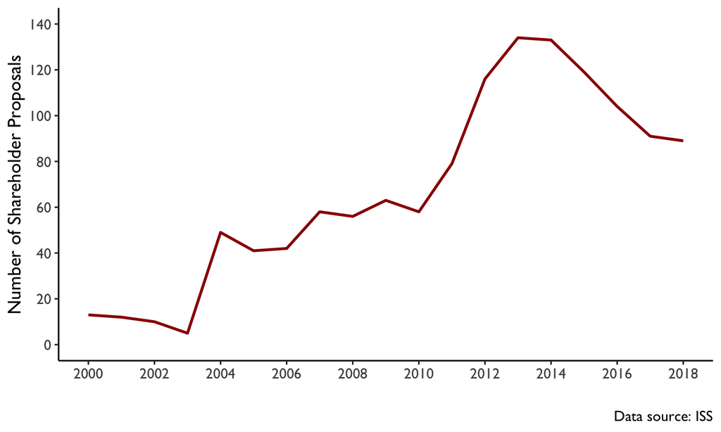

## Motivation (Cont.)

This movement is driven by public pensions,  
labor unions, SRIs, and religious groups.

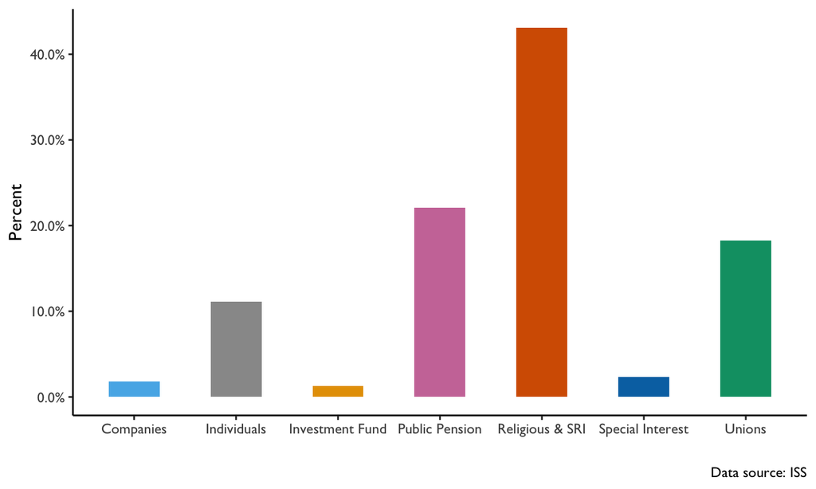

## But does it matter?

- **Can shareholder political activism disrupt corporate political and market activities?**
- **Can shareholder political activism ultimately improve corporate political transparency and accountability?**

## What We Know and Don’t Know

- **Social movements can pressure corporations for changes through market and political disruption (King and Soule 2007; McDonnell and Werner 2016).**
- **But much of sociological research focuses on disruptive tactics such as boycotts, labor strikes, protests, etc.**
- **Limited sociological studies have shown that shareholder activism can lead to market disruption (Vasi and King 2012).**
- **Numerous scholars of corporate governance have demonstrated that shareholder activism can influence corporate financial and governance performance (Denes, Karpoff, and McWilliams 2017; Goranova and Ryan 2014).**

## Significance of the Study

- **Still, it is unclear whether shareholder political activism can cause political and market disruption of the targeted firms.**

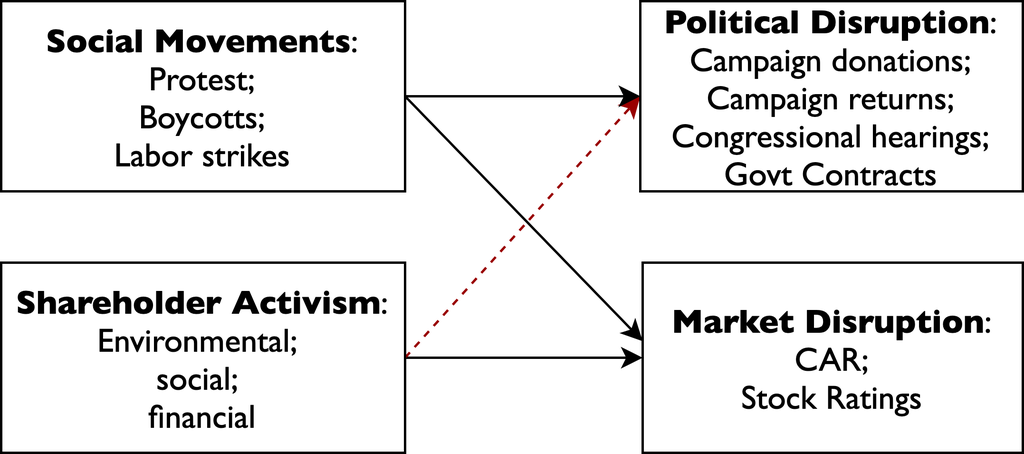

To recap, the goal is to test whether shareholder political activism leads to political and/or market disruption.

## Research Design: Define the Impact

- **Political Disruption**: Corporate PAC donations, Campaign returns, Congressional hearings, and Govt contracts.
- **Market Disruption**: The Janis-Fadner (JF) coefficient of security analysts’ stock ratings and Cumulative abnormal stock returns.

## Research Design: the DID Approach

- **To estimate the “causal” effect of shareholder political activism, I adopt the difference-in-differences approach with matching to compare non-targeted pre- and post- market and political outcomes with those of the targeted group.**

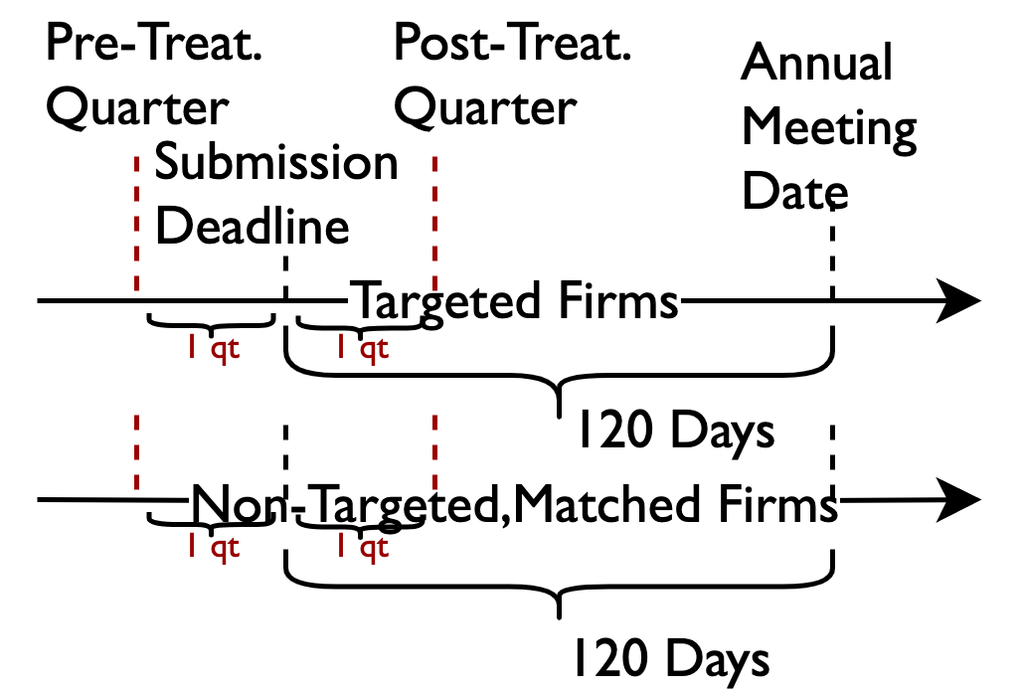

## Research Design: the DID Approach (cont.)

- **The DID estimator is specified as the interaction term between treated and post-treatment time. Treated is a dummy coded as 1 if a firm is targeted by any shareholder activists; period is a dummy coded as 1 if it is after the post-treatment period. The unit of analysis is firm-quarter.**
- **Then, I run a series of pooled OLS regressions with state, industry, year, and quarter fixed effects predicting quarterly corporate political and market outcomes.**

## The DID Analysis

**Shareholder political activism can lead to corporate political disruption, but not market disruption.**

|  | Stock Rating JF Coef. | Cumulative Abnormal Returns | PAC Donations | Campaign Returns | Congressional Hearings | Federal Govt. Contracts |
| --- | --- | --- | --- | --- | --- | --- |
| `DID` | -0.00 | -0.02 | -1.69*** | 0.05* | -0.09** | -1.33 |
| `Treated` | 0.00 | -0.03 | 2.63*** | 0.04+ | 0.06 | 5.56+ |
| `Period` | -0.00 | -0.16 | 0.43 | -0.03 | 0.01 | 1.01+ |

*Note: CoVars+Year/Quarter/Industry/State FE*

## Discussions

- **Corporate elites are influential in politics via corporate political activities;**
- **Concerned shareholders like public pensions and labor unions can use institutionalized shareholder proposal mechanism to challenge corporate elites;**
- **David Webber (2018) defines the movement led by public pensions and labor unions as the working-class shareholder activism;**
- **Similar to Webber’s conclusion that shareholder activism is labor’s last best weapon, my study shows that maybe there is some hope that powerful shareholders like NY State Public Retirement System and CalPERS can improve corporate political transparency and accountability.**

## Thank You!

**Yonjun Zhang**

Assistant Professor  
Department of Sociology and IACS  
Stony Brook University  
Yongjun.Zhang@stonybrook.edu  
https://yongjunzhang.com